# Praca domowa 2

Barbara Kozłowska

## Dane

Dane wykorzystane w Pracy domowej 2 dotyczą wyników egzaminów z 3 umiejętności: czytania, pisania i operacji matematycznych. Dodatkowo dostępne są podstawowe informacje o studentach i ich rodzicach. Opis wszystkich kolumn znajduje się również w pliku `README.md`.

| Zmienna | Opis |
| --- | --- |
| **gender** | płeć |
| **race.ethnicity** | pochodzenie etniczne |
| **parental.level.of.education** | wykształcenie rodziców |
| **lunch** | jaki obiad jedli uczniowie w dniu egzaminu |
| **test.preparation.course** | czy uczeń odbył kurs przygotowujący |
| **math.score** | wynik egzaminu z matematyki |
| **reading.score** | wynik egzaminu z czytania |
| **writing.score** | wynik egzaminu z pisania |

## Zadanie 1

Jak wyglądają rozkłady wyników uczniów z trzech przedmiotów (matematyka, czytanie, pisanie)?

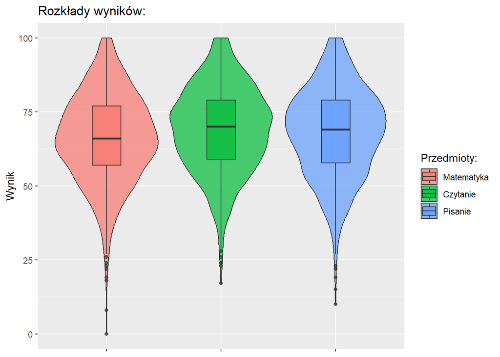

```r
df_long <- df %>%
  pivot_longer(cols = c(math.score, reading.score, writing.score),
               names_to = "przedmiot",
               values_to = "wynik")

wykres <- ggplot(df_long, aes(x = przedmiot, y = wynik, fill = przedmiot)) +
  geom_violin(alpha = 0.7) + geom_boxplot(alpha = 0.7, width=0.25) +
  scale_x_discrete(labels = NULL) +
  scale_fill_discrete(name = "Przedmioty:", labels=c("Matematyka","Czytanie","Pisanie")) +
  labs(title = "Rozkłady wyników:",x=NULL, y = "Wynik")


wykres
```

**Komentarz:** Rozkłady wyników uczniów z trzech przedmiotów rozkładają się następująco: zdecydowanie najmniejszy średni wynik jest z matematyki - wynoszący około 66 - potem wynik z pisania - około 68, zaś największy średni wynik to wynik z czytania, który wyniósł około 69. Dzięki wykresom violin oraz boxplot można powiedzieć, że 50% wyników z matematyki plasuje się między 57 a 77, z czytania między 59 a 79, z pisania między 57.75 a 79 (kwantyle między pierwszym a trzecim). Jedynie niewielka ilość outlierów z wszystkich trzech przedmiotów osiągnęła wyniki poniżej 25 (kolejno 7 z matematyki, 4 z czytania i 5 z pisania, z czego 2 osoby uzyskały ponizej 25 z wszystkich tych kategorii), ale osób, które osiągnęły wynik powyżej 95 jest znacząco więcej (kolejno 24 z matematyki, 34 z czytania i 37 z pisania, z czego 11 osób uzyskały powyżej 95 ze wszystkich tych kategorii).

## Zadanie 2

Czy istnieje zauważalna różnica w wynikach między uczniami i uczennicami?

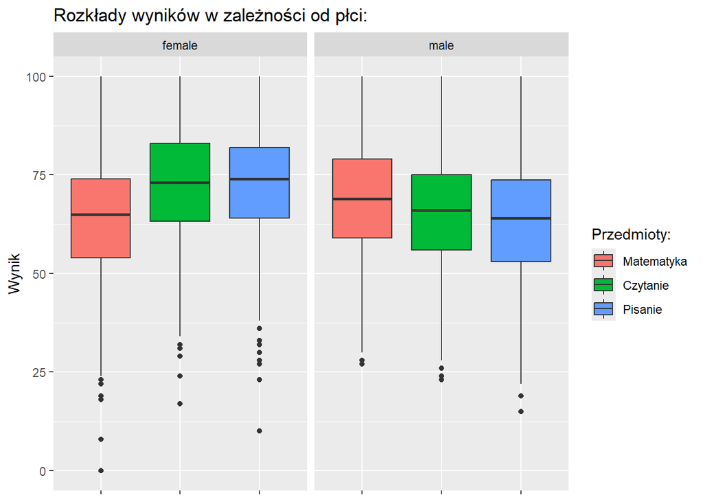

```r
box_wykres <- df %>%
  group_by(gender) %>%
  pivot_longer(cols = c(math.score, reading.score, writing.score),
               names_to = "przedmiot",
               values_to = "wynik") %>%
  ggplot(aes(x = przedmiot, y = wynik, fill = przedmiot)) +
  geom_boxplot() +
  facet_wrap(~ gender) + scale_x_discrete(labels = NULL) +
  scale_fill_discrete(name = "Przedmioty:", labels=c("Matematyka","Czytanie","Pisanie")) +
  labs(title = "Rozkłady wyników w zależności od płci:",x=NULL, y = "Wynik")

box_wykres
```

## Zadanie 3

Czy uczniowie, którzy ukończyli kurs przygotowawczy, osiągają lepsze wyniki niż pozostali?

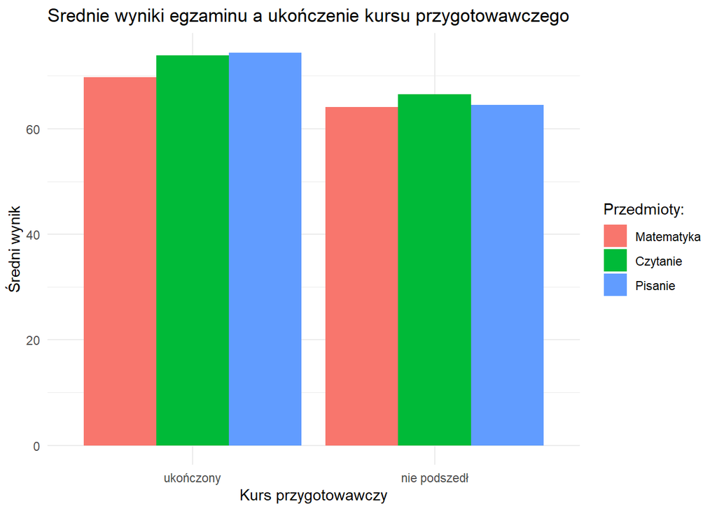

```r
kurs <- df %>%
  group_by(test.preparation.course) %>%
  summarise(srednia_m= mean(math.score),
            srednia_w = mean(writing.score),
            srednia_r = mean(reading.score)) %>%
  pivot_longer(cols = c(srednia_m,srednia_w,srednia_r),
               names_to = "typ",
               values_to = "wynik") %>%
  ggplot(aes(x=test.preparation.course, y=wynik,fill=typ)) + geom_col(position = "dodge") + theme_minimal() + labs(title="Srednie wyniki egzaminu a ukończenie kursu przygotowawczego",x="Kurs przygotowawczy",y="Średni wynik") +
  scale_x_discrete(labels = c("ukończony","nie podszedł")) + scale_fill_discrete(name = "Przedmioty:", labels=c("Matematyka","Czytanie","Pisanie"))

kurs
```

**Komentarz:** Wykorzystałam funkcję obliczania średniej, ponieważ uważam że najlepiej odzwierciedli ona wpływ ewentualnego wypełnienia kursu na wynik z danego przedmiotu. Ze wszystkich przedmiotów średni wynik uczniów, którzy ukończyli kurs przygotowawczy jest wyższy niż średni wynik tych, którzy go nie ukończyli. Osoby, które ukończyły kurs dostały średnio o : 5.7 z matematyki, 9,9 z pisania oraz 7.4 z czytania więcej punktów niż te, które go nie ukończyły.

## Zadanie 4

Jaki jest związek między poziomem wykształcenia rodziców a średnimi wynikami uczniów?

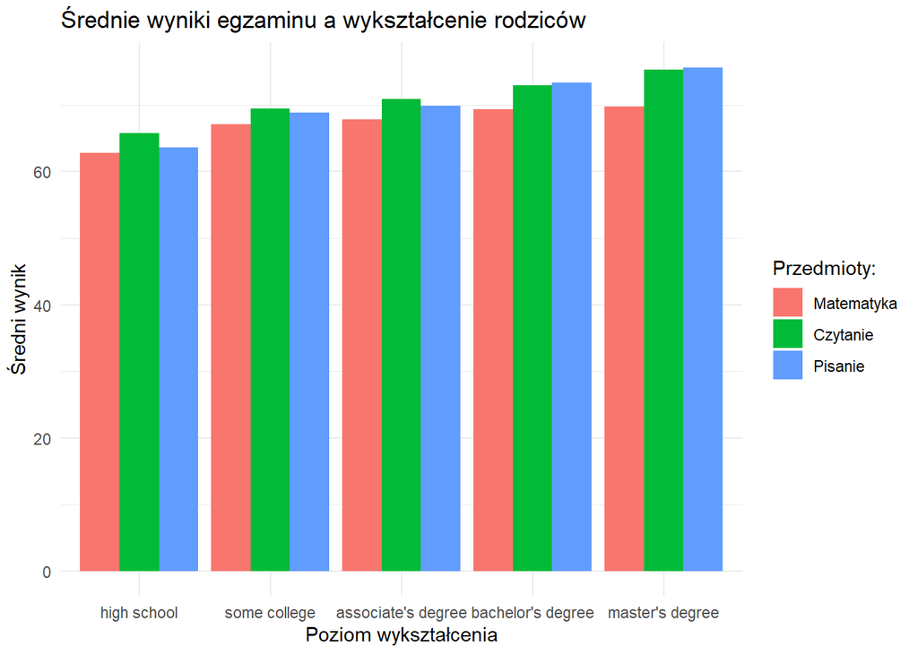

```r
wyksztalcenie <- df %>%
  mutate(parental.level.of.education = case_when(
    parental.level.of.education %in% c("some high school", "high school") ~ "high school",
    TRUE ~ parental.level.of.education
  )) %>%
  mutate(parental.level.of.education = factor(
    parental.level.of.education,
    levels = c("high school", "some college", "associate's degree",
               "bachelor's degree", "master's degree"))) %>%
  group_by(parental.level.of.education) %>%
  summarise(srednia_m = mean(math.score),
            srednia_w = mean(writing.score),
            srednia_r = mean(reading.score)) %>%
  pivot_longer(cols = c(srednia_m, srednia_w, srednia_r),
               names_to = "typ",
               values_to = "wynik") %>%
  ggplot(aes(x = parental.level.of.education, y = wynik, fill = typ)) +
  geom_col(position = "dodge") +
  theme_minimal() +
  labs(title = "Średnie wyniki egzaminu a wykształcenie rodziców",
       x = "Poziom wykształcenia",
       y = "Średni wynik") +
  scale_fill_discrete(name = "Przedmioty:",
                      labels = c("Matematyka", "Czytanie", "Pisanie"))
wyksztalcenie
```

## Zadanie 5

Czy płeć i wykształcenie rodzica wpływa na wynik z matematyki?

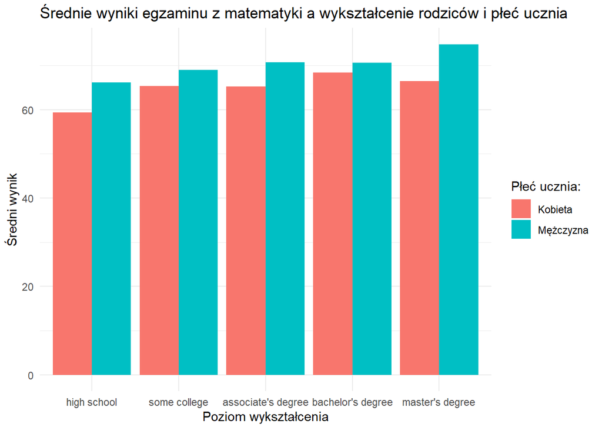

```r
math_score <- df %>%
  mutate(parental.level.of.education = case_when(
  parental.level.of.education %in% c("some high school", "high school") ~ "high school",
  TRUE ~ parental.level.of.education)) %>%
  mutate(parental.level.of.education = factor(
  parental.level.of.education,
  levels = c("high school", "some college", "associate's degree",
             "bachelor's degree", "master's degree"))) %>%
  group_by(parental.level.of.education, gender) %>%
  summarise(srednia_m= mean(math.score))  %>%
  ggplot(aes(x=parental.level.of.education, y=srednia_m, fill=gender)) + geom_col(position = "dodge") + theme_minimal() + labs(title="Średnie wyniki egzaminu z matematyki a wykształcenie rodziców i płeć ucznia",x="Poziom wykształcenia",y="Średni wynik") +
  scale_fill_discrete(name = "Płeć ucznia:", labels=c("Kobieta","Mężczyzna"))

math_score
```

**Komentarz:** Płeć ucznia oraz wykształcenie rodzica ma wpływ na wyniki uczniów z matematyki - bez względu na wykształcenie rodziców, średnie wyniki uczennic są niższe niż te uczniów. Średnie wyniki uczniów, których rodzice mają wyższe wykształcenie (some college i wyżej) są w przypadku chłopców poziomowo wyższe, zaś w przypadku dziewczynek pomimo wykształcenia rodzica średnie wyniki nie są proporcjonalnie wyższe.

## Zadanie 6

Czy istnieje zależność między wynikami z matematyki a wynikami z czytania lub pisania?

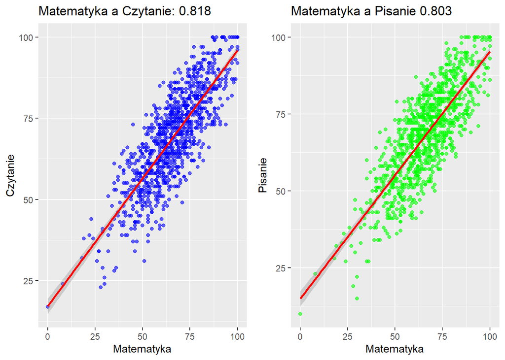

```r
cor_p1 = cor(df$math.score, df$reading.score)
cor_p2 = cor(df$math.score, df$writing.score)

p1 <- ggplot(df, aes(x = math.score, y = reading.score)) + geom_point(alpha = 0.6, color = "blue") + geom_smooth(method = "lm", color = "red") + labs(title = paste("Matematyka a Czytanie:", round(cor_p1, 3)), x = "Matematyka", y = "Czytanie")

p2 <- ggplot(df, aes(x = math.score, y = writing.score)) + geom_point(alpha = 0.6, color = "green") + geom_smooth(method = "lm", color = "red") + labs(title = paste("Matematyka a Pisanie", round(cor_p2, 3)), x = "Matematyka", y = "Pisanie")

library(gridExtra)
grid.arrange(p1, p2, ncol = 2)
```

**Komentarz:** Wyniki z matematyki są skorelowane z wynikami z czytania oraz pisania - współczynnik korelacji Pearsona wynosi kolejno 0.82 oraz 0.8, gdzie dla wyników powyżej 0.7 korelacja jest opisywana jako silna. Dodatkowo wykresy punktowe pokazują, że większość wyników koncentruje się wzdłuż linii trendu.